# 14.310x: Data Analysis for Social Scientists - Homework #5

Welcome to your fifth homework assignment! You will have about one week to work through the assignment. We encourage you to get an early start, particularly if you still feel you need more experience using R. We have provided this PDF copy of the assignment so that you can print and work through the assignment offline. You can also go online directly to complete the assignment. If you choose to work on the assignment using this PDF, please go back to the online platform to submit your answers based on the output produced. Some of the questions we are asking are not easily solvable using math so we recommend you to use your R knowledge and the content of previous homeworks to find numeric solutions. Good luck :)!

```r
# Preliminaries
rm(list = ls())
getwd()
```

```
[1] "/cloud/project/Module 5"
```

A manufacturer receives a shipment of 100 parts from a vendor. The shipment will be unacceptable if more than five of the parts are defective. The manufacturer is going to randomly select K parts from the shipment for inspection, and the shipment will be accepted if no defective parts are found in the sample.

1. How large does K have to be to ensure that the probability that the manufacturer accepts an unacceptable shipment is less than 0.1? Hint: We recommend that use R to plug in different values of K.
1. 12
2. 22
3. 32
4. 42

```r
# Manufacturer most likely to accept unacceptable shipment when unacceptable shipment has least (6) defective parts
cat("K - Probability of mistake\n")
```

```
K - Probability of mistake
```

```r
for (k in 1:94) {
  # Probability of accepting unacceptable shipment = (94 choose k) / (100 choose k)
  p_mistake <- factorial(100-k) / (95*96*97*98*99*100*factorial(94-k))
  cat(k, p_mistake, "\n")
  if (p_mistake < 0.1) break # smallest K possible
}
```

```
1 0.94
2 0.8830303
3 0.8289672
4 0.7776909
5 0.7290852
6 0.6830377
7 0.6394396
8 0.5981854
9 0.5591733
10 0.5223047
11 0.4874844
12 0.4546203
13 0.4236235
14 0.3944081
15 0.3668912
```

[output cut: 17 more lines]

2. Now suppose that the manufacturer decides to accept the shipment if there is at most one defective part in the sample. How large does K have to be to ensure that the probability that the manufacturer accepts an unacceptable shipment is less than 0.1?

```r
# Similar to the previous case. Only probability of accepting unacceptable shipment has 1 more contributing factor associated with having 1 defective part in the sample
cat("K - Probability of mistake\n")
```

```
K - Probability of mistake
```

```r
for (k in 1:94) {
  # Probability of accepting unacceptable shipment when 0 defective parts found in sample = (94 choose k) / (100 choose k)
  p_mistake0 <- factorial(100-k) / (95*96*97*98*99*100*factorial(94-k))

  # Probability of accepting unacceptable shipment when 1 defective part found in sample = (6 choose 1) * (94 choose (k-1)) / (100 choose k)
  p_mistake1 <- 6 * k * factorial(100-k) / (95*96*97*98*99*100*factorial(95-k))

  # Total probability of accepting unacceptable shipment
  p_mistake <- p_mistake0 + p_mistake1
  cat(k, p_mistake, "\n")

  if (p_mistake < 0.1) break # smallest K possible
}
```

```
1 1
2 0.9969697
3 0.9911565
4 0.9827962
5 0.9721136
6 0.9593227
7 0.9446266
8 0.9282187
9 0.9102821
10 0.8909905
11 0.8705079
12 0.8489897
13 0.8265824
14 0.8034238
15 0.7796438
```

[output cut: 36 more lines]

4. Let the number of chocolate chips in a certain type of cookie have a Poisson distribution. We want the probability that a randomly chosen cookie has at least two chocolate chips to be greater than 0.99. For which of the following values of the mean of the distribution is this condition assured. (Please select all that apply!) Hint: You may wish to try different values in R when solving this problem if you have having trouble solving the relevant equations.
1. 6
2. 7
3. 8
4. 9

```r
possible_means <- c(6, 7, 8, 9) # trials of mean/lamda
cat("Mean - Probability of at least 2 chocolate chips - Satisfied\n")
```

```
Mean - Probability of at least 2 chocolate chips - Satisfied
```

```r
for (lamda in possible_means) {
  # Probability of at least 2 chocolate chips (sum of Poisson-PMF for k = 2, 3, 4 ...)
  p_2chocolate <- ppois(1, lamda, lower.tail = FALSE)
  if (p_2chocolate > 0.99) {
    cat(lamda, p_2chocolate, "OK\n")
  }
  else {
    cat(lamda, p_2chocolate, "X\n")
  }
}
```

```
6 0.9826487 X
7 0.9927049 OK
8 0.9969808 OK
9 0.9987659 OK
```

Now we are going to perform some simulations in R. We are going to follow Sara’s example in the lecture where we imagine a case where the xi follow a uniform distribution between 0 and θ (U[0, θ]), and a researcher is trying to figure out the value of θ. (We will set θ = 5 ). We are going to simulate different random samples from this distribution with a sample size of 100 observations each. These samples will be available to the two researchers, and we are going to plot how ˆθ is distributed for different estimators. There are two types of researchers in this world: researcher A uses as an estimator for θ, ˆθA = 2 ∗ x, where x corresponds to the sample mean of the sample he receives from us. Researcher B uses as an estimator ˆθB = 2 ∗ median(x), where median(x) corresponds to the median of the sample he receives from us. We have provided you with an R code (file ‘RcodePset6Students.R’ in this folder) that has some information missing in case you need help for the exercise.

8. What would be the mean of this distribution of x?

```r
2.5
```

```
[1] 2.5
```

9. What would be the variance of the distribution of θˆA?

```r
4 * 5^2  / (12*100)
```

```
[1] 0.08333333
```

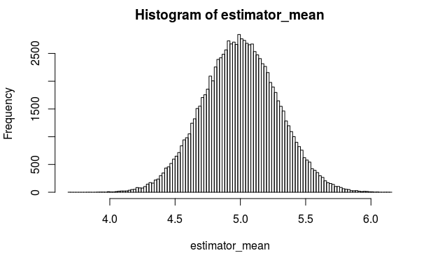

```r
#Preliminaries
rm(list = ls())
library("mvtnorm")

real_theta <- 5
sample_size <- 100
number_simulations <- 100000

# Simulated samples, each in a row
simulations1 <- matrix(runif(sample_size*number_simulations, max = real_theta), nrow = number_simulations)

# Mean estimates, median estimates
estimator_mean <- 2*apply(simulations1, 1, mean)
estimator_median <- 2*apply(simulations1, 1, median)

# Mean estimate histogram, median estimate histogram
p1 <- hist(estimator_mean, breaks = 100)
```

```r
p2 <- hist(estimator_median, breaks = 100)
range <- range(p1$mids, p2$mids) # min and max values of midpoints of bars
p1$counts = p1$density # for plotting in 'density', instead of 'counts'
p2$counts = p2$density # for plotting in 'density', instead of 'counts'

# Plot 2 histograms together
pdf("histogram1.pdf")
```

[figure not shown]

```r
plot(p1, col=rgb(1,0,0,1/4), xlim = range, xlab = "values", ylab = "density")
plot(p2, col=rgb(0,0,1,1/4), add = TRUE)
legend("topright",
       legend = c("estimator_mean", "estimator_median"),
       col =  c(rgb(1,0,0,1/4), rgb(0,0,1,1/4)),
       lty = c(1, 1),
       lwd = c(2, 2)) # Add legend
dev.off()
```

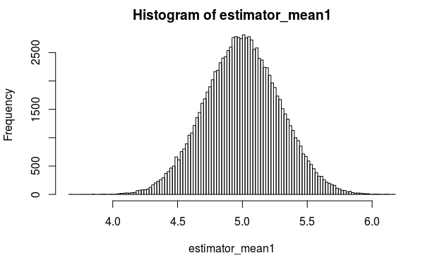

```r
# Sample size will be changed to 200 (instead of 1000) due to limited memory (1GB RAM)

# Preliminaries
rm(list = ls())

real_theta <- 5
sample_size1 <- 100
sample_size2 <- 200
number_simulations <- 100000

# Two sets of simulated samples, of 2 sizes
simulations1 <- matrix(runif(sample_size1*number_simulations, max = real_theta), nrow = number_simulations)
simulations2 <- matrix(runif(sample_size2*number_simulations, max = real_theta), nrow = number_simulations)

# Mean estimates
estimator_mean1 <- 2*apply(simulations1, 1, mean)
estimator_mean2 <- 2*apply(simulations2, 1, mean)

# Mean estimate histograms
p1 <- hist(estimator_mean1, breaks = 100)
```

```r
p2 <- hist(estimator_mean2, breaks = 100)
range <- range(p1$mids, p2$mids) # min and max values of midpoints of bars
p1$counts = p1$density # for plotting in 'density', instead of 'counts'
p2$counts = p2$density # for plotting in 'density', instead of 'counts'

# Plot histograms together
pdf("histogram_mean_estimator_2_sample_sizes.pdf")
```

[figure not shown]

```r
plot(p1, col=rgb(1,0,0,1/4), xlim = range, xlab = "values", ylab = "density")
plot(p2, col=rgb(0,0,1,1/4), add = TRUE)
legend("topright",
       legend = c("estimator_mean1", "estimator_mean2"),
       col =  c(rgb(1,0,0,1/4), rgb(0,0,1,1/4)),
       lty = c(1, 1),
       lwd = c(2, 2)) # Add legend
dev.off()
```